# final_project_Task_2

Bakro

11/27/2021

## Synnopsis

The goal of the project is to build a model that can predict the next word given an input word/sentence fragment. This report examines the three sets of writing samples and performs some exploratory analysis on them. Some 1-gram (one word at a time) to 4-gram (grouping into 4 word phrases) models are briefly examined on the samples of the datasets. For the next step, a 1-gram to n-gram model using all the text datasets will be built to predict the next word given a phrase is entered.

## summary of processing

1-Download Data and zip files (see Appendix)

2- access to files info (size,numberofwords,…) and save this info in table(see Appendix)

3- sampling data(see Appendix)

4- combine files together(see Appendix)

5- cleaning data

6- n-grams

7- ploting data

note : in steps that take long time to process or important data . i save file and load it again to save time (caching data)

## getting data and info

see Appendix that code to download data and summarize info of files

```r
## here is saved info about files
repo_summary2 <- read.csv("data/repo_summary")
repo_summary2
```

| X | names | size_Mb | lines | chars | words |
| --- | --- | --- | --- | --- | --- |
| 1 | blogs | 200.4242 | 899288 | 208361438 | 38707143 |
| 2 | news | 196.2775 | 77259 | 15683765 | 2759278 |
| 3 | twitter | 159.3641 | 2360148 | 162385035 | 31151191 |

###Data sampling

### Combind text data

The text files are then combined together.

## Checklist for cleaning data

- Removing stop words (common words to be filtered like is, am, are)
- Remove punctuation
- Remove numbers
- Remove bad words
- keep only ASCII characters

```r
conprofane <- file("data/bad-words.txt", "r")
profanity_vector <- VectorSource(readLines(conprofane))
combined_txt <- read_Text_File("data/NLP/combined_text.txt")
corpus <- VCorpus(VectorSource(combined_txt)) # main corpus with all sample files
corpus <- tm_map(corpus, removeNumbers)
corpus <- tm_map(corpus, stripWhitespace)
corpus <- tm_map(corpus, tolower)
corpus <- tm_map(corpus, removePunctuation)
corpus <- tm_map(corpus, removeWords, stopwords("english"))
corpus <- tm_map(corpus, removeWords, profanity_vector)
corpus <- gsub("http\\w+","", corpus)
save(corpus, file="data/NLP/corpus.RData")
```

## n_grams

In the fields of computational linguistics and probability, an n-gram (sometimes also called Q-gram) is a contiguous sequence of n items from a given sample of text or speech. The items can be phonemes, syllables, letters, words or base pairs according to the application. The n-grams typically are collected from a text or speech corpus. When the items are words, n-grams may also be called shingles

```r
load("data/NLP/corpus.RData") ## load clean data
ngram_tb <- tibble(line = 1:(length(corpus[[1]])), text = corpus[[1]])
```

### Unigram

```r
unigram_tb <-  ngram_tb %>%
  unnest_tokens(word, text) %>% # turn our text file into individual words
  anti_join(stop_words, by = "word") %>% # remove stop words
  filter(!str_detect(word, "\\d+")) %>% # filter digits
  filter(!str_detect(word,"[^\x01-\x7F]+"))%>% # only AScii characters
  mutate_at("word", str_replace, "[[:punct:]]", "")   # remove punctuation

head(unigram_tb)
```

| line | word |
| --- | --- |
| 1 | list |
| 1 | dependent |
| 1 | happiness |
| 1 | spy |
| 1 | zeitgeist |
| 1 | coffee |

### Bigram

```r
bigram_tb <- ngram_tb %>%
  unnest_tokens(bigram, text, token = "ngrams", n = 2) %>%
  mutate_at("bigram", str_replace, "[[:punct:]]", "") %>%
  filter(!str_detect(bigram, "\\d+")) %>%
    filter(!str_detect(bigram,"[^\x01-\x7F]+"))  %>%
  separate(bigram, c("word1", "word2"), sep = " ")


head(bigram_tb)
```

| line | word1 | word2 |
| --- | --- | --- |
| 1 | list | dependent |
| 1 | dependent | anyone |
| 1 | anyone | happiness |
| 1 | happiness | spy |
| 1 | spy | zeitgeist |
| 1 | zeitgeist | coffee |

### Trigram

```r
trigram_tb <- ngram_tb %>%
  unnest_tokens(trigram, text, token = "ngrams", n = 3) %>%
  mutate_at("trigram", str_replace, "[[:punct:]]", "") %>%
  filter(!str_detect(trigram, "\\d+")) %>%
   filter(!str_detect(trigram,"[^\x01-\x7F]+"))  %>%
  separate(trigram, c("word1", "word2", "word3"), sep = " ")

head(trigram_tb)
```

| line | word1 | word2 | word3 |
| --- | --- | --- | --- |
| 1 | list | dependent | anyone |
| 1 | dependent | anyone | happiness |
| 1 | anyone | happiness | spy |
| 1 | happiness | spy | zeitgeist |
| 1 | spy | zeitgeist | coffee |
| 1 | zeitgeist | coffee | thanks |

### Quadgram

```r
quadgram_tb <- ngram_tb %>%
  unnest_tokens(quadgram, text, token = "ngrams", n = 4) %>%
  mutate_at("quadgram", str_replace, "[[:punct:]]", "") %>%
  filter(!str_detect(quadgram, "\\d+")) %>%
 filter(!str_detect(quadgram,"[^\x01-\x7F]+"))  %>%
  separate(quadgram, c("word1", "word2", "word3", "word4"), sep = " ")

head(quadgram_tb)
```

| line | word1 | word2 | word3 | word4 |
| --- | --- | --- | --- | --- |
| 1 | list | dependent | anyone | happiness |
| 1 | dependent | anyone | happiness | spy |
| 1 | anyone | happiness | spy | zeitgeist |
| 1 | happiness | spy | zeitgeist | coffee |
| 1 | spy | zeitgeist | coffee | thanks |
| 1 | zeitgeist | coffee | thanks | ther |

### Save the ngrams with Feather

```r
if(!dir.exists(here("data/NLP/ngrams"))){
  dir.create(here("data/NLP/ngrams"))
}

# save ngrams with feather
ngrams_path <- here('data/NLP/ngrams')
write_feather(unigram_tb, here(ngrams_path, "unigrams.feather"))
write_feather(bigram_tb, here(ngrams_path, "bigrams.feather"))
write_feather(trigram_tb, here(ngrams_path, "trigrams.feather"))
write_feather(quadgram_tb, here(ngrams_path, "quadgram.feather"))
```

## Exploratory Data Analysis

### Unigrams

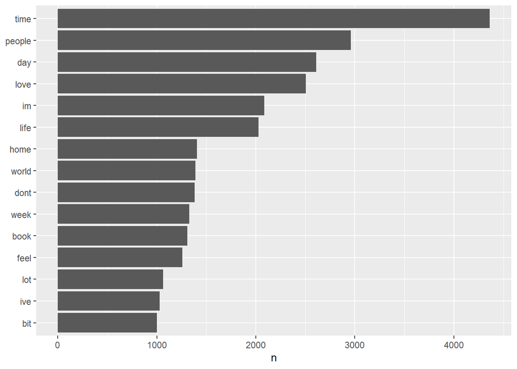

```r
unigram_tb %>%
  show_morefrequency(15)
```

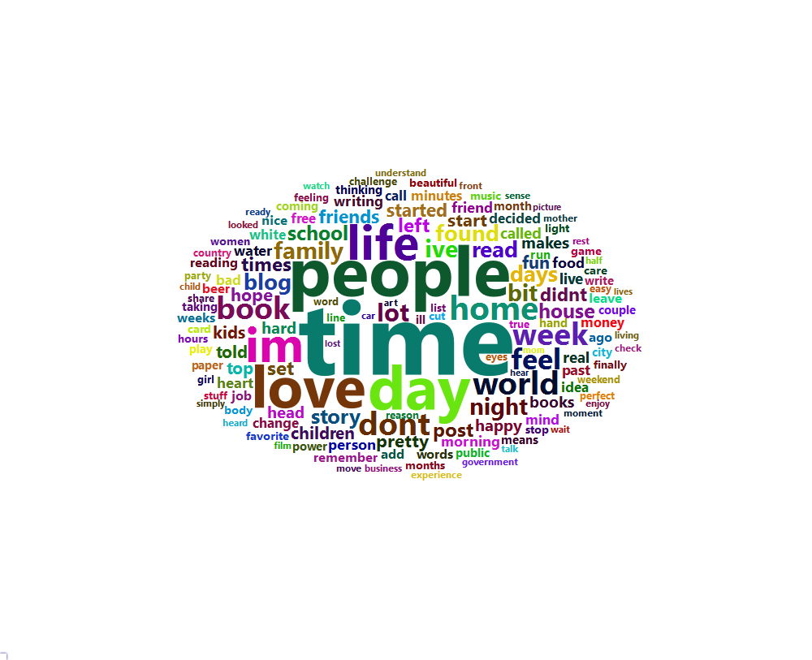

```r
 ggsave(here("figs/unigram_bar.png"), width = 12,  height = 8)

# webshot::install_phantomjs()
 # C:\Users\mjd\AppData\Roaming\PhantomJS
file_name <- "unigram_wc.png"
wordcloud(unigram_tb, file_name, 150)
knitr::include_graphics(path.expand(here("figs", file_name)))
```

### Bigrams

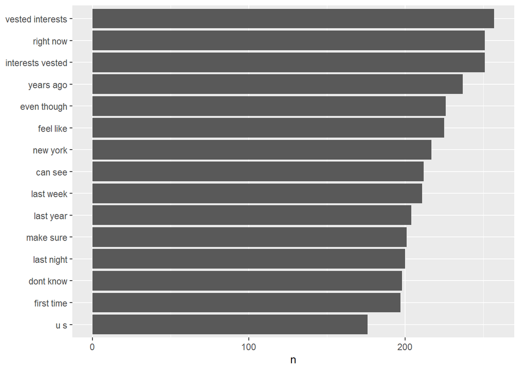

```r
bigram_tb <- bigram_tb %>%
  unite(bigram, word1, word2, sep=" ")

bigram_tb %>%
  show_morefrequency(15)
```

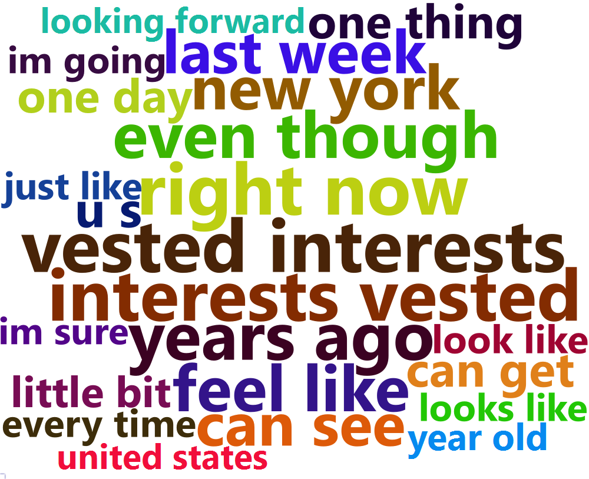

```r
ggsave(here("figs/bigram_bar.png"), width = 12,  height = 8)

file_name <- "bigram_wc.png"
wordcloud(bigram_tb, file_name, 100)
knitr::include_graphics(path.expand(here("figs", file_name)))
```

### Trigrams

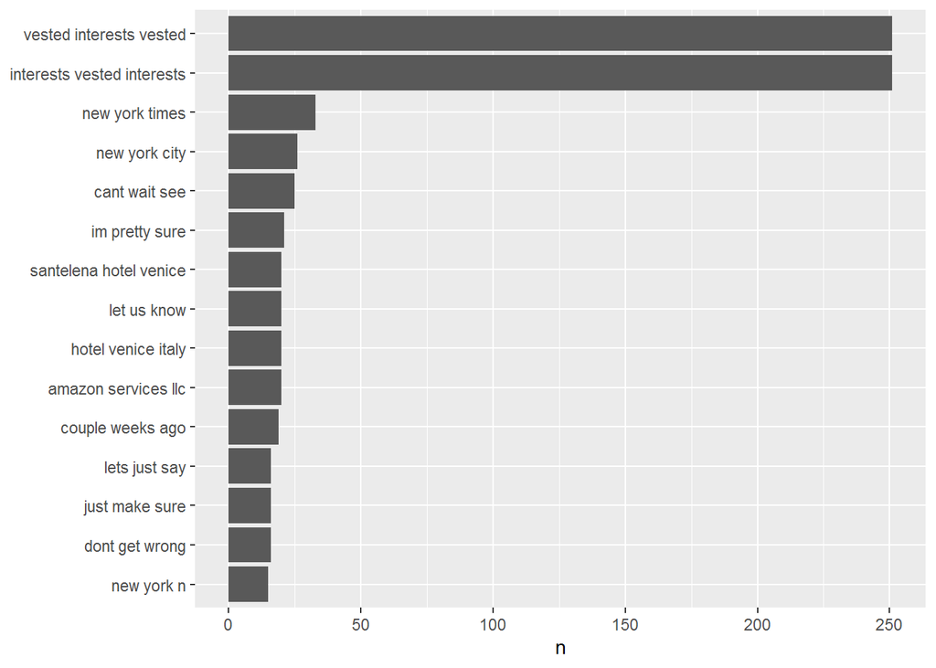

```r
trigram_tb <- trigram_tb %>%
  unite(bigram, word1, word2, word3, sep=" ")

trigram_tb %>%
  show_morefrequency(15)
```

[figure not shown]

```r
ggsave(here("figs/trigram_bar.png"), width = 12,  height = 8)

file_name <- "trigram_wc.png"
wordcloud(trigram_tb, file_name, 100)
knitr::include_graphics(path.expand(here("figs", file_name)))
```

## Document Term matrix

```r
my_dtm <- ngram_tb %>%
  unnest_tokens(word, text) %>%
  count(line, word) %>%
  cast_dtm(line, word, n)
my_dtm
```

```
## <<DocumentTermMatrix (documents: 1, terms: 73538)>>
## Non-/sparse entries: 73538/0
## Sparsity           : 0%
## Maximal term length: 80
## Weighting          : term frequency (tf)
```

## Plan for NLP model and Shiny app

The analysis helped me understand more about what kind of information my sampled data captures. With a dtm ready, the next step is to get more data for testing and validation, then build the model. After that, I will start building the shiny app for users to use the data product. Throughout the process, I will by studying more from the book Tidy text mining and research suitable algorithms to use.

The steps are summarized below:

Prepare train test and validation dataset

I will split my current dtm into a train and test set, then randomly sample more data to create my validation dataset. Train and evaluate text prediction model

I will be training multiple suitable models on the training set, then evaluate their performance on the test set. The best performing model will be chosen, and applied on the validation set in the end. Build shiny app

After finishing the model, I will apply it to the shiny app, Users will then be able to type up words in a text box, and the model will generate predictions from the words. Slide deck

With a working data product, the last step is to build a slide deck using R presentations and present to users how to use the product.

## Appendix

### download data

```r
download_data  <- function(locale, outdir) {
    here::i_am("report/milestone-report.Rmd")
    data_path <- here("data")

    if (dir.exists(here(data_path, outdir))) {
        print("directory already exists")
    } else {
        options(timeout = 200) # to prevent timeout error

        # download data into temp file
        temp <- tempfile()
        download.file(url = "https://d396qusza40orc.cloudfront.net/dsscapstone/dataset/Coursera-SwiftKey.zip",
                      temp)

        # unzip tempfile and remove
        unzip(zipfile = temp, exdir = data_path)
        unlink(temp)
    }

    # save directory of extracted zip file
    final_path <- here(data_path, "final")

    # create outdir directory
    dir.create(here(data_path, outdir))

    # grabs files with en_US
    old_names <-
        list.files(
            path = final_path,
            pattern = paste0("^", locale),
            recursive = TRUE
        )

    # provide new names
    new_names <- c("blogs.txt", "news.txt", "twitter.txt")

    # rename and remove old ones.
    file.rename(from = file.path(final_path, old_names),
                to = file.path(here(data_path, outdir), new_names))

    # remove final folder from zip file
  unlink(here(data_path, "final"), recursive = TRUE)
}
```

### file info

```r
blogs_file   <- "./data/final/en_US/en_US.blogs.txt"
news_file    <- "./data/final/en_US/en_US.news.txt"
twitter_file <- "./data/final/en_US/en_US.twitter.txt"

# create txt file
read_Text_File <- function(path) {
    con <- file(path, "r")
    text <- readLines(con, skipNul = T)
    close(con)
    return(text)
}


blogs <- read_Text_File(blogs_file)
news <- read_Text_File(news_file)
twitter <- read_Text_File(twitter_file)

blogs_size <- file.size(blogs_file)/(1024*1024)
news_size   <- file.size(news_file)/(1024*1024)
twitter_size <- file.size(twitter_file)/(1024*1024)
blogs_lines   <- length(blogs)
news_lines    <- length(news)
twitter_lines <- length(twitter)

blogs_nchar_sum   <- sum(nchar(blogs))
news_nchar_sum    <- sum(nchar(news))
twitter_nchar_sum <- sum(nchar(twitter))


blogs_words <- sum(str_count(blogs,'\\w+'))

news_words  <-  sum(str_count(news,'\\w+'))
twitter_words <- sum( str_count(twitter,'\\w+'))

repo_summary <- data.frame(names = c("blogs", "news", "twitter"),
                           size_Mb  = c(blogs_size, news_size, twitter_size),
                           lines = c(blogs_lines, news_lines, twitter_lines),
                           chars =  c(blogs_nchar_sum, news_nchar_sum, twitter_nchar_sum),
                           words = c(blogs_words, news_words, twitter_words))

write.csv(repo_summary,file = "data/repo_summary")
repo_summary %>%
  kbl() %>%
  kable_styling(bootstrap_options = c("striped", "hover"))
```

### helping methods

```r
read_Text_File <- function(path) {
    con <- file(path, "r")
    text <- readLines(con, skipNul = T)
    close(con)
    return(text)
}

show_morefrequency <- function(tibble, top_num) {
    tibble %>%
        rename(ngram = colnames(tibble)[2]) %>%
        count(ngram, sort = TRUE) %>%
        slice(1:top_num) %>%
        mutate(ngram = reorder(ngram, n)) %>%
        ggplot(aes(n, ngram)) +
        geom_col() +
        labs(y = NULL)
}

wordcloud <- function(tibble, file_name, top_num=100) {
  wordcloud <- tibble %>%
    rename(ngram = colnames(tibble)[2]) %>%
    count(ngram, sort = TRUE) %>%
    slice(1:top_num) %>%
    wordcloud2(size=0.7, color='random-dark', minRotation = 0, maxRotation = 0)

  saveWidget(wordcloud, "tmp.html", selfcontained = F)
  webshot("tmp.html", here("10_DataScienceCapstone/figs", file_name), delay = 5, vwidth = 1000, vheight = 800)

  unlink(here("10_DataScienceCapstone/report", "tmp_files"), recursive = TRUE)
  unlink(here("10_DataScienceCapstone/report", "tmp.html"))
}
```

### sampling data

```r
set.seed(2021)
blogs_file   <- "./data/final/en_US/en_US.blogs.txt"
news_file    <- "./data/final/en_US/en_US.news.txt"
twitter_file <- "./data/final/en_US/en_US.twitter.txt"
# prob is probability of sampling
sample_data("blogs", blogs_file, prob = 0.05)
sample_data("news", news_file, prob = 0.2)
sample_data("twitter", twitter_file, prob = 0.01)

sample_path <- here("data/sampled")
list.files(sample_path)

sample_data <- function(filename, filepath, prob) {
    set.seed(2021)
    con <- file(filepath, "r")
    file <- readLines(con, skipNul = T)
    len <- length(file)
    sub_file <- file[rbinom(n = len, size = 1, prob = prob) == 1]
    close(con)

    sample_path <- here("data/sampled")
    if (!dir.exists(sample_path)) {
        dir.create(sample_path)
    }

    new_file_path <- paste0(sample_path, "/sub_", filename)
    if (!file.exists(new_file_path)) {
        out <- file(new_file_path, "w")
        writeLines(sub_file, con = out)
        close(out)
    }
}
```

### combine data

```r
sample_path <- here("data/sampled")
list.files(sample_path)
sampled_file_names <- list.files(sample_path)

blogs_txt <- read_Text_File(here(sample_path, sampled_file_names[1]))
news_txt <- read_Text_File(here(sample_path, sampled_file_names[2]))
twitter_txt <- read_Text_File(here(sample_path, sampled_file_names[3]))

combined_txt <- paste(c(twitter_txt, news_txt, blogs_txt))
combined_txt <- sent_detect(combined_txt, language = "en", model = NULL) # splitting of text paragraphs into sentences.
    new_file_path <- here("data/NLP/combined_text.txt")
    if (!file.exists(new_file_path)) {
        out <- file(new_file_path, "w")
        writeLines(combined_txt, con = out)
        close(out)
    }
# clear from memory
rm("twitter_txt", "news_txt", "blogs_txt")
```